# Lab14

```r
library(tidyverse)
```

## Exercise 1.

Consider data set USArrests.

Look at the means and standard deviations of features of the data set USArrests. Which is the variable with highest variance?

```r
USArrests |> summarize(across(everything(), .fns=~mean(.x)))
```

| Murder | Assault | UrbanPop | Rape |
| --- | --- | --- | --- |
| 7.788 | 170.76 | 65.54 | 21.232 |

```r
USArrests |> summarize(across(everything(), .fns=~sd(.x)))
```

| Murder | Assault | UrbanPop | Rape |
| --- | --- | --- | --- |
| 4.35551 | 83.33766 | 14.47476 | 9.366385 |

Find principal components by using scaling of variables. Look at the components of results. Do you understand, what is the meaning of those components?

```r
glimpse(ex1.1)
```

```
List of 5
 $ sdev    : num [1:4] 1.575 0.995 0.597 0.416
 $ rotation: num [1:4, 1:4] -0.536 -0.583 -0.278 -0.543 -0.418 ...
  ..- attr(*, "dimnames")=List of 2
  .. ..$ : chr [1:4] "Murder" "Assault" "UrbanPop" "Rape"
  .. ..$ : chr [1:4] "PC1" "PC2" "PC3" "PC4"
 $ center  : Named num [1:4] 7.79 170.76 65.54 21.23
  ..- attr(*, "names")= chr [1:4] "Murder" "Assault" "UrbanPop" "Rape"
 $ scale   : Named num [1:4] 4.36 83.34 14.47 9.37
  ..- attr(*, "names")= chr [1:4] "Murder" "Assault" "UrbanPop" "Rape"
 $ x       : num [1:50, 1:4] -0.976 -1.931 -1.745 0.14 -2.499 ...
  ..- attr(*, "dimnames")=List of 2
  .. ..$ : chr [1:50] "Alabama" "Alaska" "Arizona" "Arkansas" ...
  .. ..$ : chr [1:4] "PC1" "PC2" "PC3" "PC4"
 - attr(*, "class")= chr "prcomp"
```

```r
ex1.1$rotation
```

```
                PC1        PC2        PC3         PC4
Murder   -0.5358995 -0.4181809  0.3412327  0.64922780
Assault  -0.5831836 -0.1879856  0.2681484 -0.74340748
UrbanPop -0.2781909  0.8728062  0.3780158  0.13387773
Rape     -0.5434321  0.1673186 -0.8177779  0.08902432
```

Verify that principal components are computed by multiplying scaled data (which can be obtained by scale(USArrests)) with matrix containing direction vectors of components). Matrix multiplication is %*% in R.

```r
scale(USArrests) %*% ex1.1$rotation - ex1.1$x
```

```
               PC1 PC2 PC3 PC4
Alabama          0   0   0   0
Alaska           0   0   0   0
Arizona          0   0   0   0
Arkansas         0   0   0   0
California       0   0   0   0
Colorado         0   0   0   0
Connecticut      0   0   0   0
Delaware         0   0   0   0
Florida          0   0   0   0
Georgia          0   0   0   0
Hawaii           0   0   0   0
Idaho            0   0   0   0
Illinois         0   0   0   0
Indiana          0   0   0   0
Iowa             0   0   0   0
Kansas           0   0   0   0
Kentucky         0   0   0   0
Louisiana        0   0   0   0
Maine            0   0   0   0
Maryland         0   0   0   0
Massachusetts    0   0   0   0
Michigan         0   0   0   0
Minnesota        0   0   0   0
Mississippi      0   0   0   0
Missouri         0   0   0   0
Montana          0   0   0   0
Nebraska         0   0   0   0
Nevada           0   0   0   0
New Hampshire    0   0   0   0
New Jersey       0   0   0   0
New Mexico       0   0   0   0
New York         0   0   0   0
North Carolina   0   0   0   0
North Dakota     0   0   0   0
Ohio             0   0   0   0
Oklahoma         0   0   0   0
Oregon           0   0   0   0
Pennsylvania     0   0   0   0
Rhode Island     0   0   0   0
South Carolina   0   0   0   0
South Dakota     0   0   0   0
Tennessee        0   0   0   0
Texas            0   0   0   0
Utah             0   0   0   0
Vermont          0   0   0   0
Virginia         0   0   0   0
Washington       0   0   0   0
West Virginia    0   0   0   0
Wisconsin        0   0   0   0
Wyoming          0   0   0   0
```

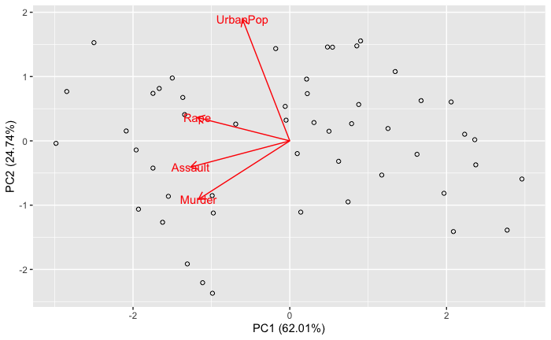

Direction vectors are determined only up to multiplying with -1, so different implementations of PCA can produce different pictures. Produce a graph with first two principal components and loading vectors if all direction vectors are chosen to have opposite directions from the original result. Hint: multiply component matrix and rotation matrix with -1.

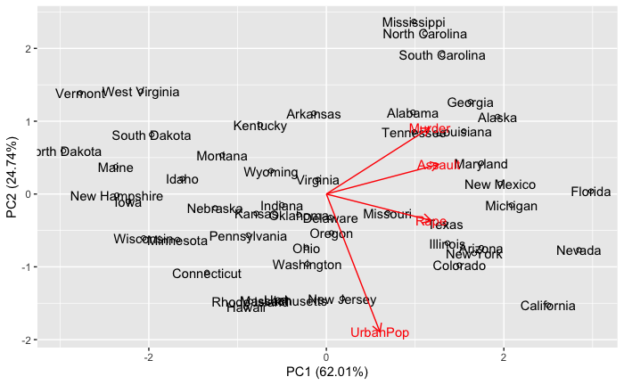

Produce a scree plot (plot of variance of a component divided by the total variance) of PCA result

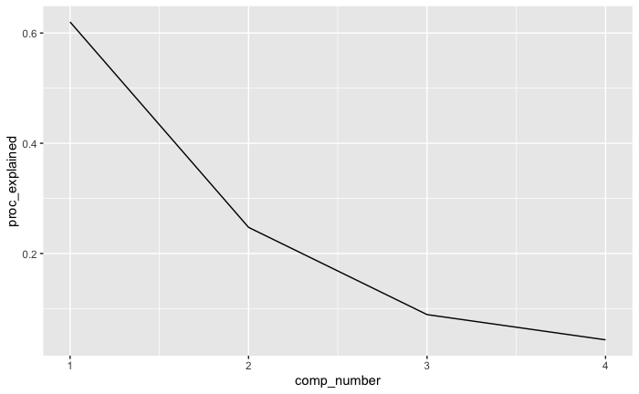

Analyze the results if scaling of variables were not used.

```r
glimpse(ex1.2)
```

```
List of 5
 $ sdev    : num [1:4] 83.73 14.21 6.49 2.48
 $ rotation: num [1:4, 1:4] 0.0417 0.9952 0.0463 0.0752 -0.0448 ...
  ..- attr(*, "dimnames")=List of 2
  .. ..$ : chr [1:4] "Murder" "Assault" "UrbanPop" "Rape"
  .. ..$ : chr [1:4] "PC1" "PC2" "PC3" "PC4"
 $ center  : Named num [1:4] 7.79 170.76 65.54 21.23
  ..- attr(*, "names")= chr [1:4] "Murder" "Assault" "UrbanPop" "Rape"
 $ scale   : logi FALSE
 $ x       : num [1:50, 1:4] 64.8 92.8 124.1 18.3 107.4 ...
  ..- attr(*, "dimnames")=List of 2
  .. ..$ : chr [1:50] "Alabama" "Alaska" "Arizona" "Arkansas" ...
  .. ..$ : chr [1:4] "PC1" "PC2" "PC3" "PC4"
 - attr(*, "class")= chr "prcomp"
```

```r
ex1.2$rotation
```

```
                PC1         PC2         PC3         PC4
Murder   0.04170432 -0.04482166  0.07989066 -0.99492173
Assault  0.99522128 -0.05876003 -0.06756974  0.03893830
UrbanPop 0.04633575  0.97685748 -0.20054629 -0.05816914
Rape     0.07515550  0.20071807  0.97408059  0.07232502
```

## Exercise 2.

Consider data set ISLR::NCI60.

use glimpse to see the format of the data set

```r
glimpse(ISLR::NCI60)
```

```
List of 2
 $ data: num [1:64, 1:6830] 0.3 0.68 0.94 0.28 0.485 ...
  ..- attr(*, "dimnames")=List of 2
  .. ..$ : chr [1:64] "V1" "V2" "V3" "V4" ...
  .. ..$ : chr [1:6830] "1" "2" "3" "4" ...
 $ labs: chr [1:64] "CNS" "CNS" "CNS" "RENAL" ...
```

```r
ISLR::NCI60 |> summarize(across(everything(), .fns=~mean(.x)))
```

[output not shown]

Look at the standard deviations of numerical features. what are the smallest and largest values of standard deviations of gene expressions?

```r
summary(sd_vals)
```

```
   Min. 1st Qu.  Median    Mean 3rd Qu.    Max.
 0.2014  0.4571  0.5651  0.6964  0.8029  3.4238
```

```r
sum(abs(v1) > 0.06)
```

```
[1] 12
```

```r
range(v1)
```

```
[1] -0.07495135  0.05251494
```

[figure not shown]

## Exercise 3 (for extra practice)

Install package rsvd and load the dataset digits from it. Note that in the first column there are labels of actual handwritten digits, which we leave out of PCA; remaining columns are pixels of digits.

Look at the first digit by forming a 28*28 matrix of the pixels and then by using the command image(digit_matrix[,28:1], col = gray(255:0 / 255)) Check if on the pairwise plots of the first 3 principal components it is possible to separate different digits (select 50 digits from each class for producing graphs)